# Graphics

OS in Rust

## Homework

- Homeworks are due on the Friday *after* the week they correspond to lecture.
- So 9 days after the corresponding lab.

## Requirements

Be advised this is a multistage lab that is intended to be interesting rather than easy.

1. Create a `src/colors.rs` to display all background colors.
2. Display and screendump the background colors to `.ppm`
3. Extract hex values from the `.ppm`
4. Create a script to convert images from url to VGA buffer array
   1. Download
   2. Scale
   3. Color map
   4. Output to `src/colors/img.rs` as a datatype of some kind.
5. Add a function to `src/colors.rs` to display the image in `src/img.rs`.
   1. And call the function from `src/main.rs

## Step 0

- Complete the “Format” lab.

## Step 1

> Add a function to `src/main.rs` to display all background colors in `qemu` via the VGA buffer.
- For this lab, we will display images using the VGA text buffer background color.
- To do that, we need to know what colors we have.
- To learn what colors we have, we will first display all of them.

### Colors

- I created a new file.
  - I am planning to not use it after the lab so I factored it out.

```
src/colors.rs
```

```rust
pub fn colors() {
    // I had 9 total lines here.
    // 1 line was in an unsafe block (which was 3 lines total)
}
```

### Main

- There are two minor changes to main.
  - I call `colors` in `_start` and nothing else.
  - I add `mod colors;` early in the file.

```
src/main.rs
```

```rust
#![no_std]
#![no_main]

mod colors;
mod vga;

#[panic_handler]
fn panic(info: &core::panic::PanicInfo) -> ! {
    println!("{}", info);
    loop {}
}

#[unsafe(no_mangle)]
pub extern "C" fn _start() -> ! {
    colors::colors();
    loop {}
}
```

## Step 2

### The Monitor

- `qemu` has more features than I can recall anymore; most of them very cool.
- One is the “Monitor”
- Within the QEMU window, you can use

  `Ctrl+Alt+2`
- From here, you can input a variety of commands.
  - [Read more](https://qemu-project.gitlab.io/qemu/system/monitor.html)
- At least try `help` and have at least on thought about it.
  - `qemu` is listed on a job ad for a Google position in Portland starting at 113k/yr as I type this.

### Screendump

- Try to following.
  - You can choose your own filename.
  - I used `dump.ppm`
  - You will want to use `.ppm`

```bash
screendump dump.ppm
```

- QEMU documentation states:

> Save screen into PPM image *filename*.

## Step 3

> Extract hex values from the `.ppm`

### PPM files

- The PPM file format is ancient and I’m not sure of the authoritative documentation.
- This appears correct to me. https://netpbm.sourceforge.net/doc/ppm.html
- You don’t need to dwell on it overlong but:
  - There is a header that gives the filetype, the size, and highest brightness value.
  - There’s a block write of pixels.

### `head`

- It is trivial to verify you have a well formed PPM file.
  - We use `head` to read the first $n$ lines of a file.
  - We use `-3` to specify that $n=3$
  - Only the first 3 lines are human readable.

```bash
head -3 dump.ppm
```

- If you do not see the following, something went wrong.

```bash
P6
720 400
255
```

- This states that:
  - You have a PPM image of type P6, this is the most common format (there is a less used P3)
  - Your image is 720 by 400 pixels
  - Brightness is out of 255.
- From here I perceive 2 “obvious” options.
  - Use some combination of `head`, `tail`, `hexdump` and other command line utilities to extract all hex values.
  - Use Python, NumPy, and PIL, all of which you likely have on your device, to extract all hex values.
  - Be advised you can compute the precise location of the first instance of every color in either a `.ppm` file or a NumPy array as you have perfect knowledge about the number of pixels.
- These two are free:

```python
import numpy as np
from PIL import Image

IMG_NAME = "dump.ppm"

img = np.array(Image.open(IMG_NAME))
print(img[0][:10])
```

```bash
cat dump.ppm | tail -1 | head -c4 | hexdump
```

- I ended up using Python here because I was going to use Python for the next step.
  - Unless?

## Step 4

> Create a script to convert images from url to VGA buffer array
1. Download
2. Scale
3. Color map
4. Output to `src/img.rs` as a (Rust) datatype of some kind.

The following instructions assume students will proceed using Python’s NumPy package. This fulfills a secondary learning objective of familiarity with vector operations that were discussed briefly here.

- As a fun bit, you may want to set up your script to optionally accept a URL at command line.
  - I did this, and it made testing a bit easier.
  - I *also* had an `IMG_URL` pointed at something that would otherwise display if there was no argument.

**Extension for Advanced Students**

Advanced students will already be familiar with these operations and with Python. They should complete Step 4 in CUDA C++, fulfilling the extension learning objective of familiarity with GPU programming and bus operations as mediated by the host/device metaphor. If you do not have access to a physical NVIDIA GPU, I provide instructions on usage in Colab [here](https://github.com/cd-public/coluda/blob/main/GPU_CUDA.ipynb).

Learning CUDA is straight-forward and an all-around good time. Learning C++ is quite the opposite. By combining both, you can practice moderation.

[CUDA Programming Guide](https://docs.nvidia.com/cuda/cuda-programming-guide/)

### Use of Numpy

#### Download

Given this is an advanced class, I’m going to trust you to do the following without providing example code.

- Regard it as “unsporting” to download a file and work with a local copy.
- Use `requests` to get an image by url.
  - You can [read this](https://cd-public.github.io/courses/cs1/slides/requests.html)
  - You can use [this URL](https://cd-public.github.io/ai101/images/photo-cat.jpg)

  ```
  https://cd-public.github.io/ai101/images/photo-cat.jpg
  ```

- Use `BytesIO` to interpret the HTTP response as a file.
- Use PIL’s `Image` API to open the image.
  - You can read this
- Coerce the image to a NumPy array using NumPy.

##### Images

I only got `.jpg` and `.webp` to work for some reason, but it’s not a big deal and you aren’t required to learn `PIL`.

- I took [this](https://cd-public.github.io/ai101/images/photo-cat.jpg) myself so it is definitely free to use.
  - Her name is Ursula.

  ```
  https://cd-public.github.io/ai101/images/photo-cat.jpg
  ```

- [This](https://www.leadvilletwinlakes.com/wp-content/themes/yootheme/cache/ba/View-of-Mount-Massive-LCTP-Cropped-scaled-ba58e696.webp) is a wide picture that should be fine, from a tourism bureau.
  - Read more

  ```
  https://www.leadvilletwinlakes.com/wp-content/themes/yootheme/cache/ba/View-of-Mount-Massive-LCTP-Cropped-scaled-ba58e696.webp
  ```

- And maybe the best for testing, an Adobe Stock rainbow.
  - The url looked unstable so I’m [rehosting](https://cd-rs.github.io/os/img/rainbow.jpg).
  - Hopefully *I’m* hosting stably.

  ```bash
  https://cd-rs.github.io/os/img/rainbow.jpg
  ```

#### Scale

- Do I look like I know how to scale images?
  - Probably either sample or average.
  - I don’t think I care.
- My code scales to fit the VGA buffer horizontally.
  - Then either “squish” or “stretch” vertically.
  - You could also crop horizontally.
    - Doesn’t matter to me.
  - Recall, the VGA buffer has more pixels than we are addressing.
  - You can only address characters, which are many pixels in size.
  - Your image will be *low* resolution.

#### Color Map

**Code Structure Note**

I included my code extracting hex-values from `dump.ppm` here.

I thought it made more sense than making a new file, it shared similar imports, and was only a few lines.

Plus, if I run on another system, which may have a different color representation, I’ll be able to quickly generate the `.ppm` and have no other steps!

- You image will include colors that cannot be recognized by the VGA text buffer.
- You will need to compute color distance between the
  - Color you are trying to show, and
  - The 16 available colors you computed in a previous step.
- A naive approach would be to regard colors in 3-space with dimensions of `R`, `G`, and `B` values.
  - This is appropriate, but sub-optimal.
  - So it’s what I did.

**Extension for Advanced Students**

Advanced students will already be familiar with distance in $n$-space and hexcodes and should use a perceptually uniform color space. In this case, `L*a*b`.

[Read more](https://en.wikipedia.org/wiki/CIELAB_color_space)

There is first class support in Python, I hear, and you can learn more from this poster, but one of Professor Brown’s undergraduate researchers.

[Poster](https://luebke.us/publications/pdf/vss2019.poster1.pdf)

You are doing this in NumPy to take advantage of vectorized operations.

- [Read more](https://cd-public.github.io/scicom/05_numpy.html#vectorization)
- Regard it as “unsporting” to use loops for a single pixel.
  - I didn’t vectorize across the full pixel array because I converted to a string in the same stage (as a list comprehension).
  - You will want to look up “argmin”.

#### Output

    ```bash
    $ wc url_to_rs.py src/colors/img.rs
    22   75  704 url_to_rs.py
     0 2006 9257 src/colors/img.rs
    ```

- I wrote to `src/colors/img.rs` as it was *I think* the place a file used by `src/colors.rs` should be.
  - I didn’t love this because I had to make a new directory.
    - I just `mkdir` once rather than scripting this step.
  - Do whatever you want here, as long as your `url_to_rs.py` writes to the right place.

## Step 5

- Add a `image()` function to `src/colors.rs` that:
  - Reads the image data from `src/colors/img.rs`
  - Writes the image data to the VGA text buffer as background colors.
- Call this function from `src/main.rs`
- Look at your image.

### Example

- Here is my result over the “Mt. Massive” image from the tourism bureau.

#### Original

- Hosting cross-site.

[figure not shown]

#### VGA Text Buffer

- Extracted to `.ppm`, converted to `.png`, converted to base64 and directly embedded.

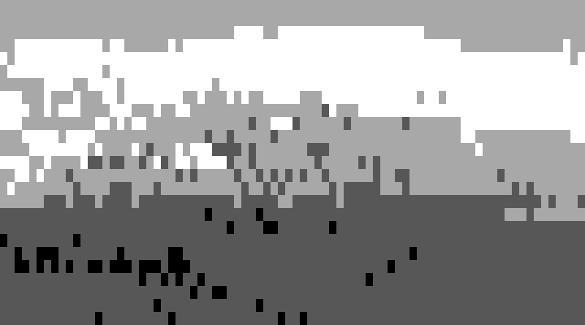